# OFB_Pre-processing Neighbourhood Survey

Eileen Murphy

2024-07-12

### Read in OFB Neighborhood Survey

```r
library(readr)

OFB_wide <- read.csv("OFB_2023/OFB_neighbour_survey_v1.0/neighbour_survey_clean-2024-06-14.csv", stringsAsFactors = FALSE)

## Change id to numeric index

OFB_wide <- OFB_wide |>
  mutate(id = as.integer(substring(id,3,8)))
```

### Validate Data Frame

#### Checking for duplicates and invalid keys (id)

```r
paste("No Duplicates: ", !anyDuplicated(OFB_wide$id))
```

```
## [1] "No Duplicates:  FALSE"
```

```r
paste("rows", nrow(OFB_wide))
```

```
## [1] "rows 4074"
```

```r
paste("columns", ncol(OFB_wide))
```

```
## [1] "columns 136"
```

```r
print("Duplicate Ids:")
```

```
## [1] "Duplicate Ids:"
```

```r
print(OFB_wide$id[duplicated(OFB_wide$id)])
```

```
##  [1]   NA   NA   NA   NA   NA   NA   NA   NA   NA   NA   NA   NA   NA   NA   NA   NA   NA
## [18]   NA   NA 3980 3983 3981 3982
```

### Deleted duplicates and any NA’s still in key fields

```r
library(dplyr)

# Deletes NA values in key id field

OFB_wide <- OFB_wide |>
  filter(!is.na(id))

OFB_wide <- OFB_wide[!duplicated(OFB_wide$id), ]
```

### Verifying Duplicate deletions - should only be 4 rows (not 8)

```r
OFB_wide |>
  select(id) |>
  filter(id %in% c(3980, 3983, 3981, 3982))
```

```
##     id
## 1 3980
## 2 3983
## 3 3981
## 4 3982
```

### Verification there are no more duplicates

```r
print("Duplicate Ids:")
```

```
## [1] "Duplicate Ids:"
```

```r
print(OFB_wide$id[duplicated(OFB_wide$id)])
```

```
## integer(0)
```

### Checking for NA’s in ind field - should be zero

```r
#colSums(is.na(OFB_wide ))

#better way
sum(is.na(OFB_wide[, c("id")]) )
```

```
## [1] 0
```

### Reshape neighborhood data from wide to long

```r
library(tidyr)

OFB_long <- OFB_wide %>%
  pivot_longer(
    cols = starts_with("q0"),
    names_to = "Question",
    values_to = "Response"
  )

library(dplyr)

OFB_long |> arrange(Question)
```

```
## # A tibble: 546,750 × 3
##       id Question Response
##    <int> <chr>    <chr>
##  1   757 q001     English
##  2   318 q001     English
##  3   328 q001     English
##  4   646 q001     English
##  5   678 q001     English
##  6   682 q001     English
##  7   772 q001     English
##  8   782 q001     English
##  9   784 q001     English
## 10   847 q001     English
## # ℹ 546,740 more rows
```

```r
print(OFB_long)
```

```
## # A tibble: 546,750 × 3
##       id Question Response
##    <int> <chr>    <chr>
##  1   757 q001     English
##  2   757 q002     No
##  3   757 q003     Often true
##  4   757 q004     Often true
##  5   757 q005     Yes
##  6   757 q006     Almost every month
##  7   757 q007     Yes
##  8   757 q008     Yes
##  9   757 q009     More than 10 years ago
## 10   757 q010     Other
## # ℹ 546,740 more rows
```

### Making sure OFB_long is formatted correctly

```r
str(OFB_long)
```

```
## tibble [546,750 × 3] (S3: tbl_df/tbl/data.frame)
##  $ id      : int [1:546750] 757 757 757 757 757 757 757 757 757 757 ...
##  $ Question: chr [1:546750] "q001" "q002" "q003" "q004" ...
##  $ Response: chr [1:546750] "English" "No" "Often true" "Often true" ...
```

### View responses to see any inconsitencies

```r
OFB_long |> distinct(Response)
```

[output not shown]

### Fix inconsistent reponses

```r
library(stringr)
OFB_long_fixed <- OFB_long |>
  mutate(Response = ifelse(str_detect(Response, "^[:upper:]+$"), Response,str_to_title(Response)))
```

### Exploring Univariate Data

### Top 20 Food Banks in Ottawa

Because this is a text field, there are many missing values unfortunately. Here we pull up the top 20 Food Banks that clients listed.

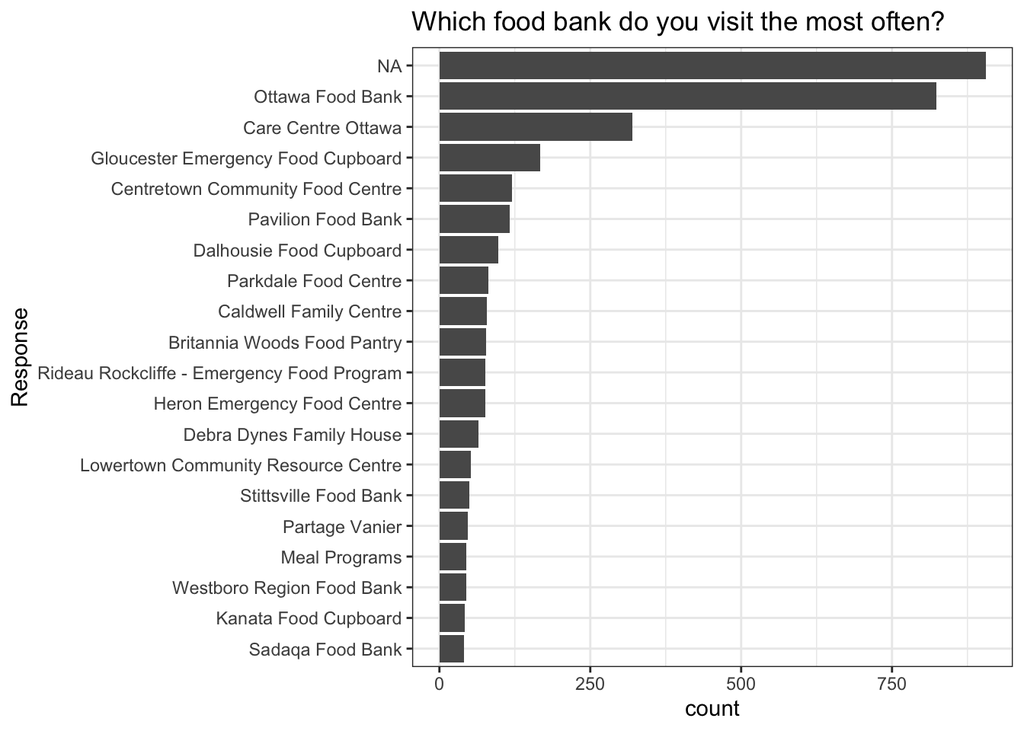

### As we can see, there are many NA’s in this text field

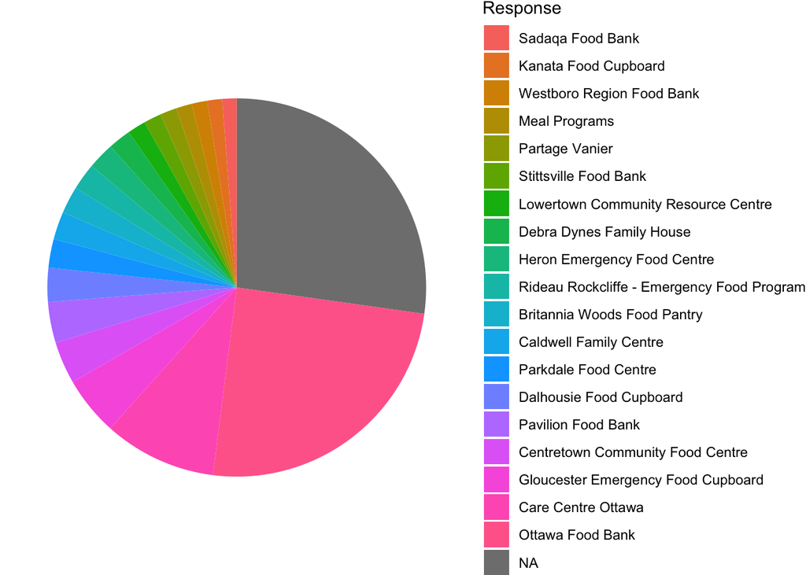

### Language of Survey

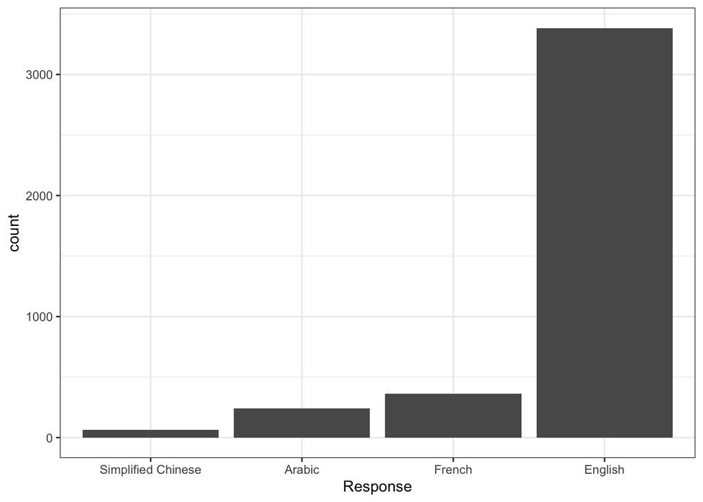

### Is income enough to meet food needs

#### Personal income is not enough to meet food needs for most people.

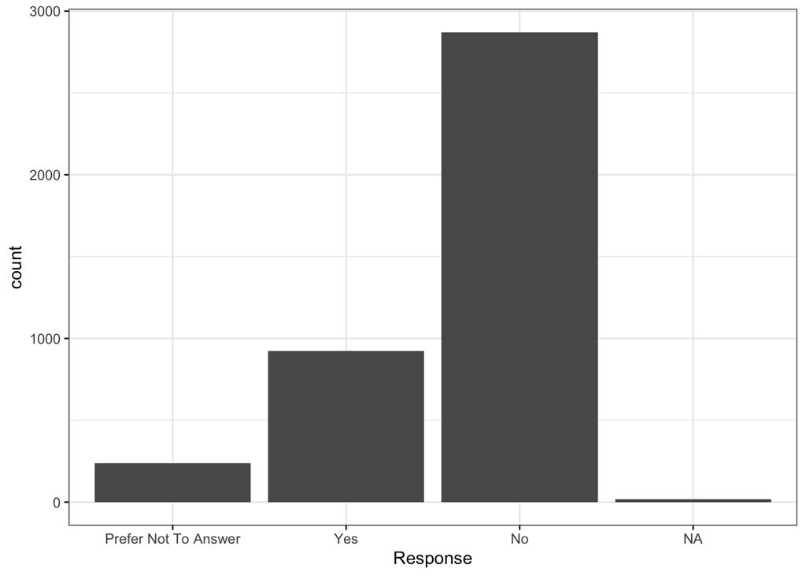

### When was using the Food Bank the first time

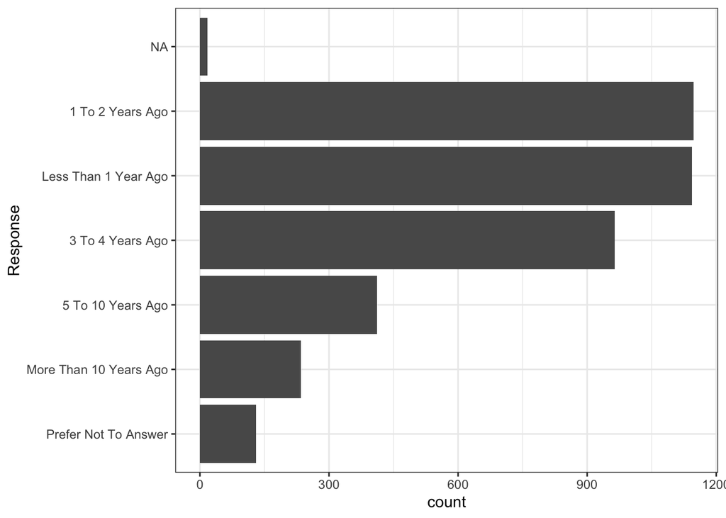

### How often going to a food bank

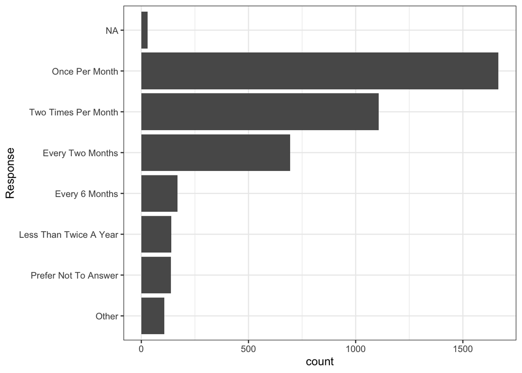

### Age

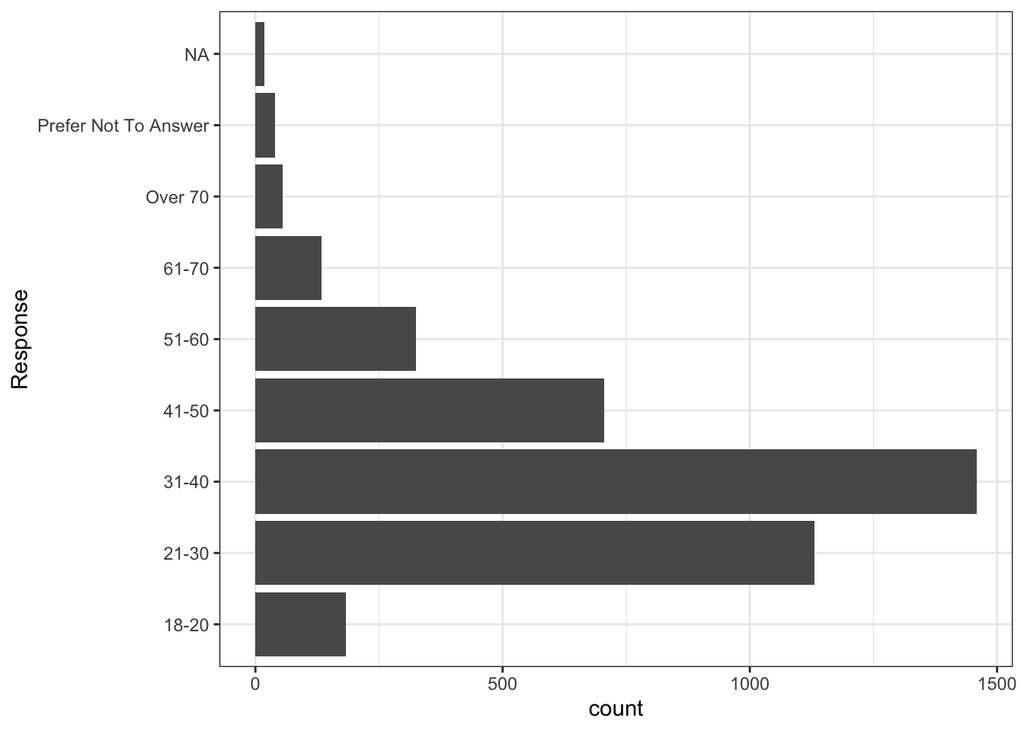

### Pregnant

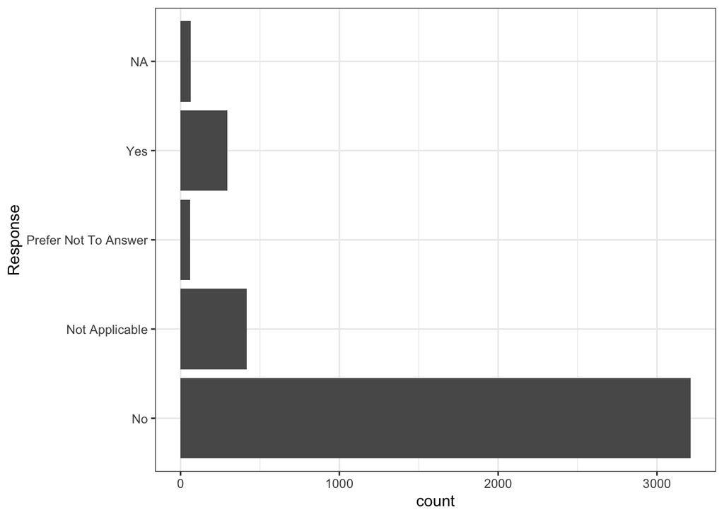

### How many in household

Most respondents are from households between 2-4 people.

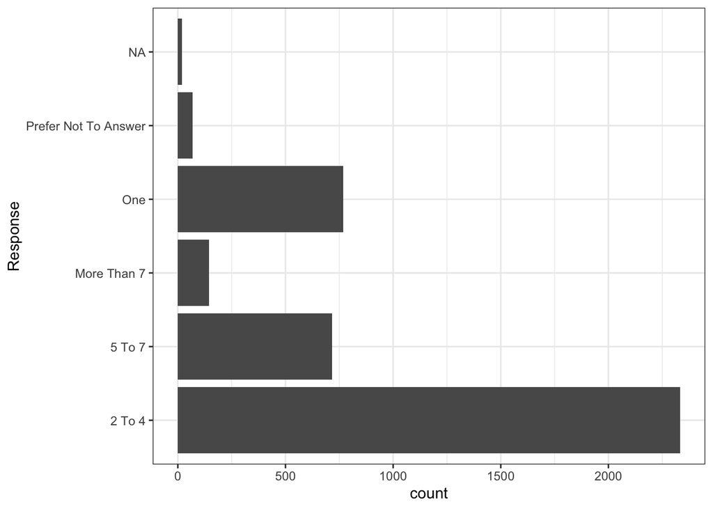

### Children

Most respondents indicated that they have children.

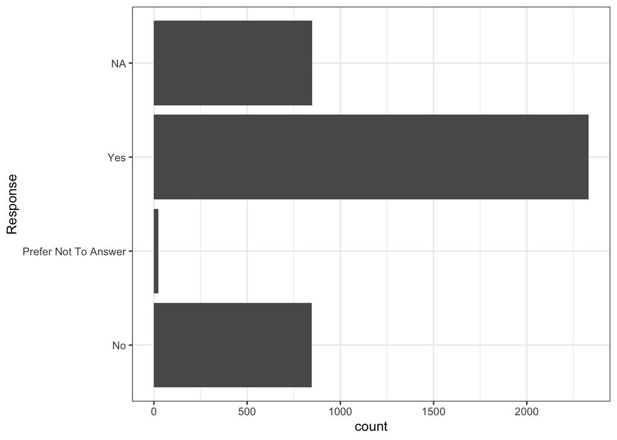

### How long in Canada

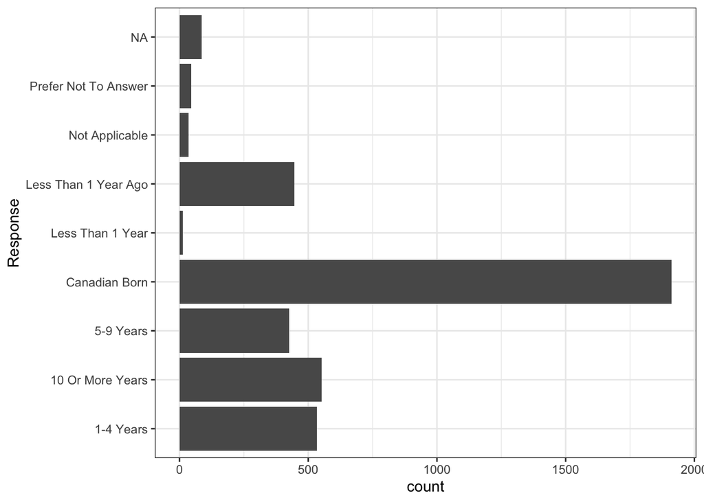

### Gender

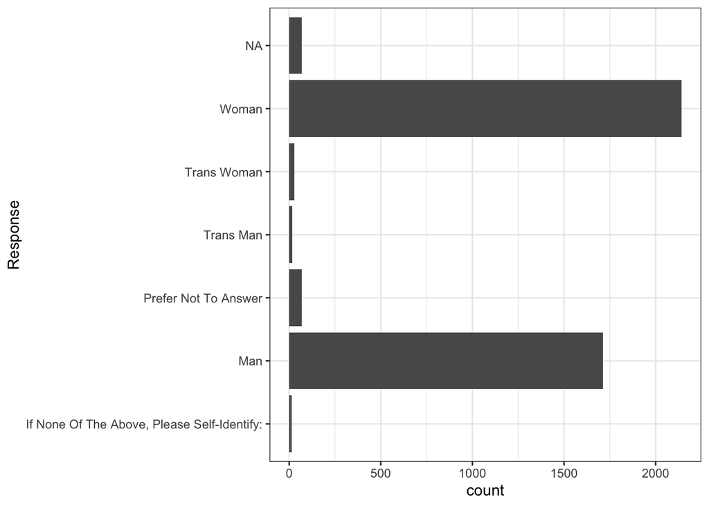

### How many years ago you started using the food bank

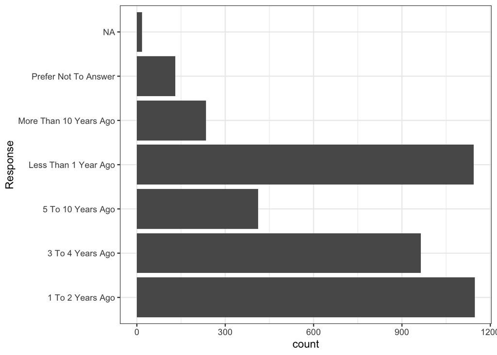

### Food Insecurity in last 12 months

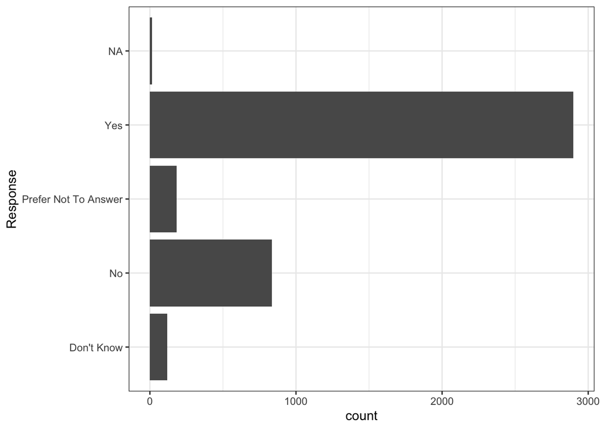

### How often visiting a food program that is not a food bank

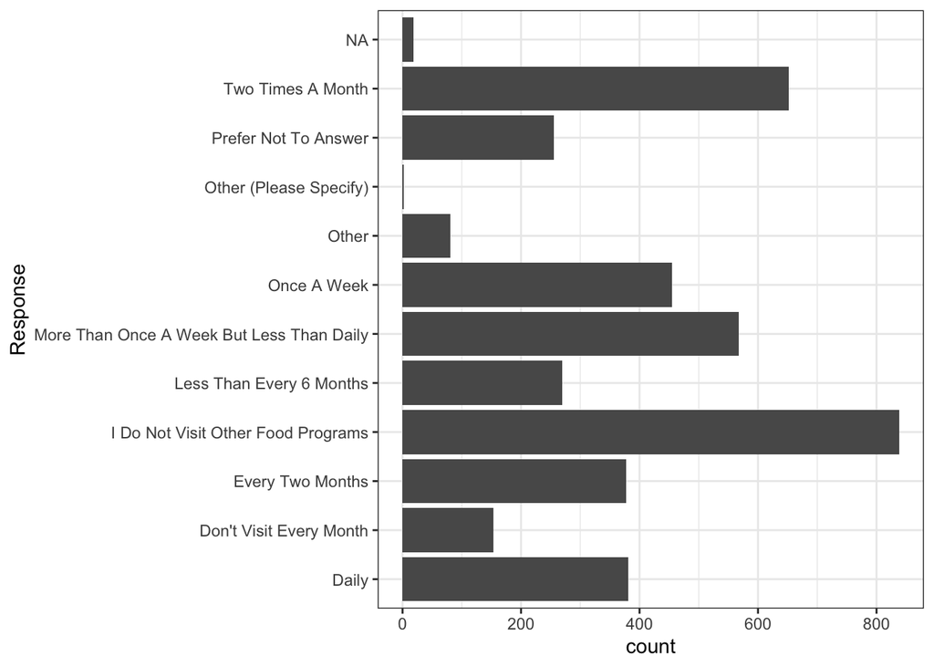

### How long does it take you to get to a food bank

Most clients can reach the food bank within the hour from leaving their home.

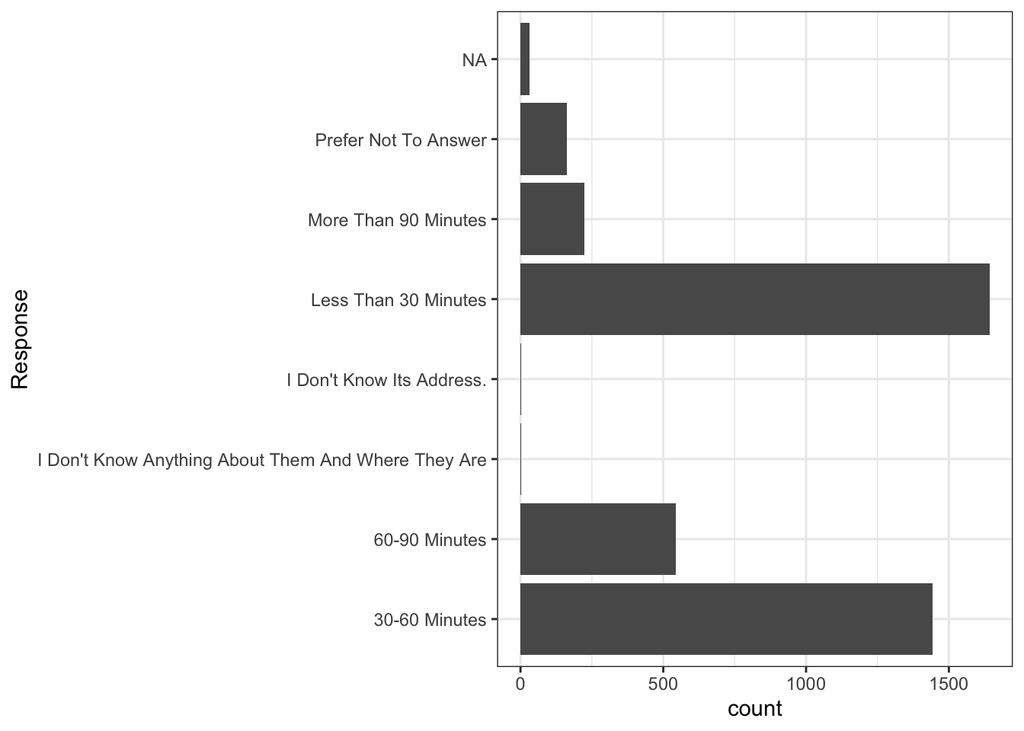

### Status in Canada

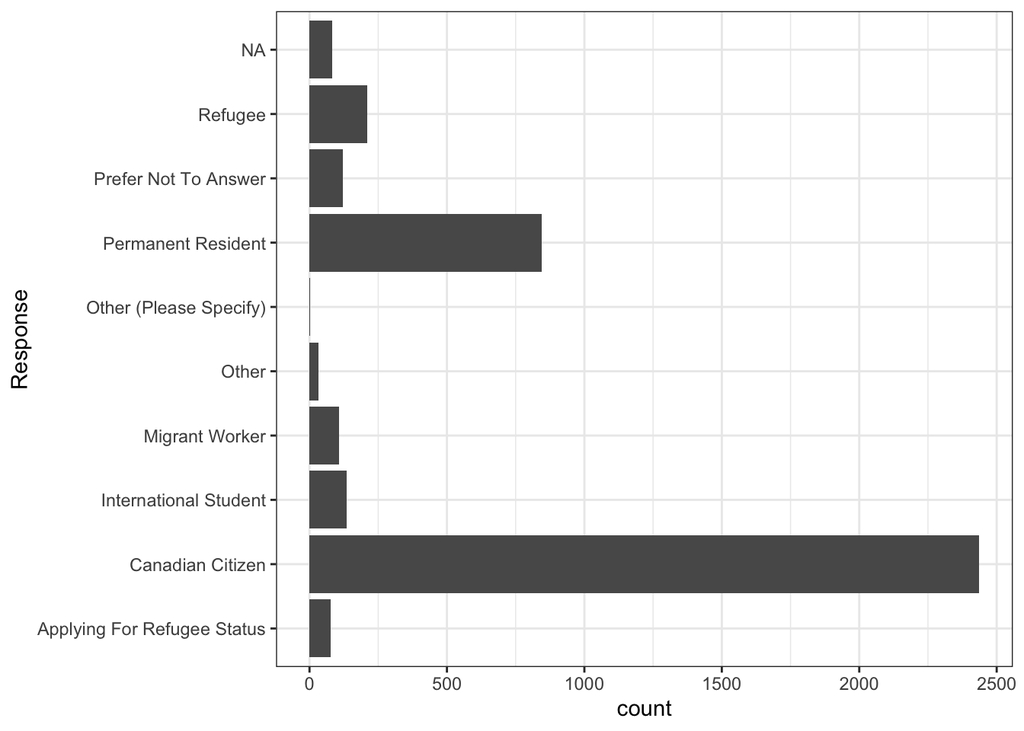

### Current living situation

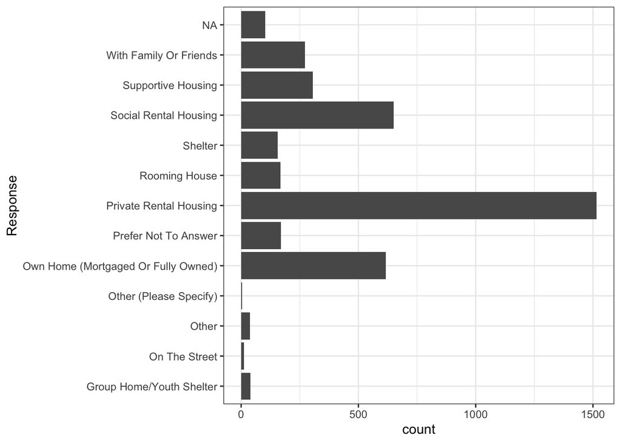

Based on the format of the question number, we are creating factor, boolean, and text fields datasets. The factor and boolean datasets are merged and the text fields are left out for privacy and processing speed reasons for now.

### Extracting and converting into factor, boolean, and text fields

```r
## Identify text fields from table and create vector

text_fields = c("q011b","q012"
                         ,"q014h"
                         ,"q016f"
                         ,"q017k"
                         ,"q018"
                         ,"q021"
                         ,"q023f"
                         ,"q024i"
                         ,"q029"
                         ,"q030"
                         ,"q031"
                         ,"q032"
                         ,"q035b"
                         ,"q036"
                         ,"q038k"
                         ,"q039i"
                         ,"q040b"
                         ,"q042"
                         )

# Creates vector of fields that are factors (excemptions) rather than boolean fields

factor_fields <- c("q011a"
                   ,"q035a"
                   ,"q036a"
                   ,"q040a"
                   ) #the exceptions


# Creating OFB_long_text dataset

OFB_long_text <- OFB_long_fixed |>
  filter(Question %in% text_fields
                         )

# Creates table with only Boolean values minus text and factor fields

OFB_long_boolean <- OFB_long_fixed |>
  filter(str_count(trimws(Question)) > 4 ) |>
  filter(!(Question %in% text_fields)) |>
  filter(!(Question %in% factor_fields))

# Extracts all boolean responses and converts them to boolean values

OFB_long_boolean <- OFB_long_boolean |>
  mutate(Response=ifelse(!is.na(Response), 1, NA ))

OFB_long_boolean <- OFB_long_boolean |> mutate(Response = as.integer(Response))

# Extracts all factor fields and factors the fields

OFB_long_factor <- OFB_long_fixed |>
  filter(str_count(trimws(Question)) <= 4 | Question %in% factor_fields ) |>
  filter(!(Question %in% text_fields))


OFB_long_factor <- OFB_long_factor |> mutate(Response = as.factor(Response))

# Extracts all comment(text) fields

OFB_long_text <- OFB_long_fixed |>
  filter(Question %in% text_fields)

OFB_wide_boolean <- OFB_long_boolean %>%
  pivot_wider(names_from = Question, values_from = Response)

OFB_wide_factor <-  OFB_long_factor %>%
  pivot_wider(names_from = Question, values_from = Response)
```

### Merging OFB_wide_factor and OFB_wide_boolean

```r
# Convert all OFB_longs to wide then cbind them together

## Convert Factors to wide


OFB_wide_factor <- OFB_long_factor %>%
  pivot_wider(names_from = Question, values_from = Response)

### Convert Boolean to wide

# Convert Boolean NA's to 0's

OFB_long_boolean <- OFB_long_boolean |>
  mutate(Response=ifelse(is.na(Response), 0, Response))

OFB_wide_boolean <- OFB_long_boolean %>%
  pivot_wider(names_from = Question, values_from = Response)



OFB_wide <- merge(OFB_wide_factor, OFB_wide_boolean)
```

### Aggregating using OFB_long_boolean

```r
library(dplyr)

OFB_long_boolean |>
  select(-id) |>
   mutate(Response=ifelse(is.na(Response), 0, Response)) |>
   group_by(Question, Response) |>
   filter(Response != 0) |>
   summarise(count = n())
```

[output not shown]

```
## # A tibble: 94 × 3
## # Groups:   Question [94]
##    Question Response count
##    <chr>       <dbl> <int>
##  1 q014a           1  1186
##  2 q014b           1   600
##  3 q014c           1   497
##  4 q014d           1   460
##  5 q014e           1  1282
##  6 q014f           1   796
##  7 q014g           1   200
##  8 q016a           1  1356
##  9 q016b           1   524
## 10 q016c           1  1988
## # ℹ 84 more rows
```

Calculate Food Insecurity Ref: https://www.ers.usda.gov/media/8282/short2012.pdf

### Calculating Food Status Score

Used factor levels to differentiate between affirmative and not.

```r
food_security <- OFB_wide_factor |>
  select(id, q003, q004, q005, q006, q007, q008)

###q003

food_security$q003 <- factor(food_security$q003, exclude=c("Prefer Not To Answer", "Don't Know"), levels=c("Never True", "Often True", "Sometimes True"))

###q004

food_security$q004 <- factor(food_security$q004, exclude=c("Prefer Not To Answer", "Don't Know"), levels=c("Never True", "Often True", "Sometimes True"))

###q005

food_security$q005 <- factor(food_security$q005, exclude=c("Don't Know", "Prefer Not To Answer"), levels=c("No","Yes"))

###q006

food_security$q006 <- factor(food_security$q006, exclude=c("Don't Know","Prefer Not To Answer"), levels=c("Did Not Happen", "Only 1 or 2 Months", "Some Months But Not Every Month", "Almost Every Month"))

###q007

food_security$q007 <- factor(food_security$q007, exclude=c("Don't Know", "Prefer Not To Answer"), levels=c("No", "Yes"))

###q008

food_security$q008 <- factor(food_security$q008, exclude=c("Don't Know", "Prefer Not To Answer"), levels=c("No", "Yes"))

food_security <- food_security |>
  mutate(q003_ = ifelse(is.na(q003),0,1),
         q004_ = ifelse(is.na(q004),0,1),
         q005_ = ifelse(q005 == "No", 0,1),
         q006_ = ifelse(q006 == "Did Not Happen", 0, 1),
         q007_ = ifelse(q007 == "No",0,1),
         q008_ = ifelse(q008 == "No",0,1))

#Convert NAs to 0 for calc

food_security <- food_security |>
  mutate(q003_=ifelse(is.na(q003_), 0, q003_),
        q004_=ifelse(is.na(q004_), 0, q004_),
        q005_=ifelse(is.na(q005_), 0, q005_),
        q006_=ifelse(is.na(q006_), 0, q006_),
        q007_=ifelse(is.na(q007_), 0, q007_),
        q008_=ifelse(is.na(q008_), 0, q008_))

#Sum up values for food security calculation
food_security <- food_security |>
  mutate(FSC=q003_ +
            q004_ +
            q005_ +
            q006_ +
            q007_ +
            q008_)
```

### Create FSC_Calc just using required fields

```r
FSC_Calc <- food_security |>
  select(id, FSC)
```

Food security status is assigned as follows:  
 Raw score 0-1—High or marginal food security  
 Raw score 2-4—Low food security  
 Raw score 5-6—Very low food security

### Creating Food Security Status from FSC score

```r
FSC_Calc <- FSC_Calc |>
  mutate(FS_Status = case_when(FSC >= 5 ~ "Very low food security",
         between (FSC,2,4) ~ "Low food security",
         between (FSC,0,1) ~ "High or marginal food security"))
```

### Food Security Status

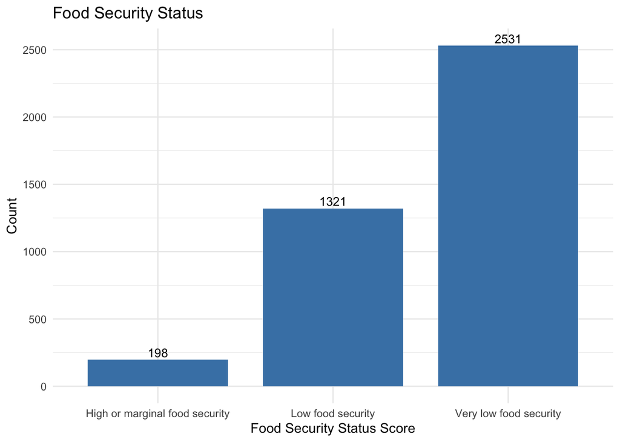

### Finishing up - Update OFB_wide for analysis

```r
OFB_wide <- merge(OFB_wide, FSC_Calc)
```

### New OFB_wide contains only factors and booleans not text fields

```r
paste("Duplicates: ", anyDuplicated(OFB_wide$id))
```

```
## [1] "Duplicates:  0"
```

```r
paste("rows", nrow(OFB_wide))
```

```
## [1] "rows 4050"
```

```r
paste("columns", ncol(OFB_wide))
```

```
## [1] "columns 121"
```

### Write to csv file - if needed

```r
#write_csv2(OFB_wide, "OFB_wide.csv")
```